# Background

An NBA playoff series is a set of games played until one team wins four games. The maximum number of games in a series is seven since both teams could win three games apiece and the seventh game is the series-deciding game. We refer to this structure as a “best of seven series.” In this presentation, we’ll be modeling the impact of winning a single game on the overall probability of winning a series. We’ll also examine how we can approach this model a frequentist and Bayesian perspective.

# Data Exploration

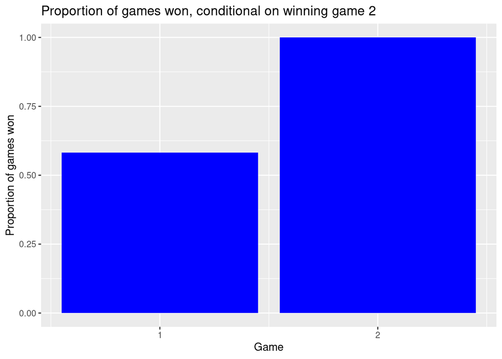

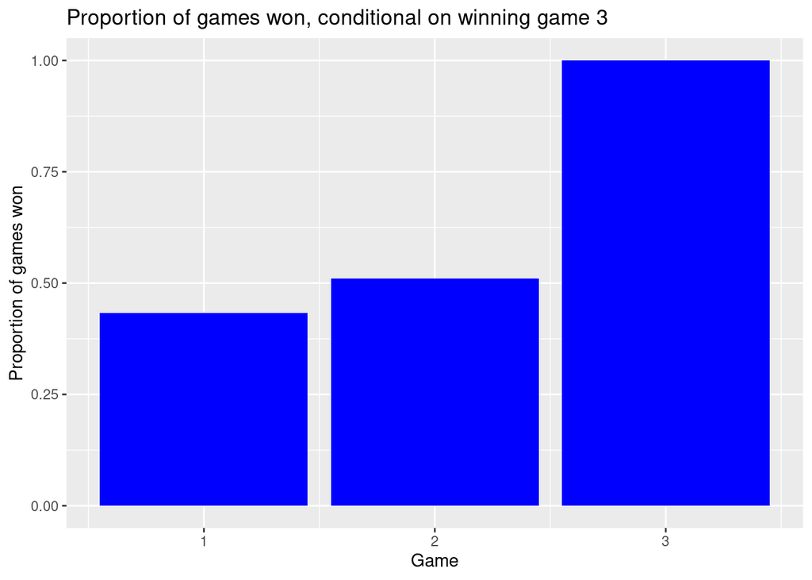

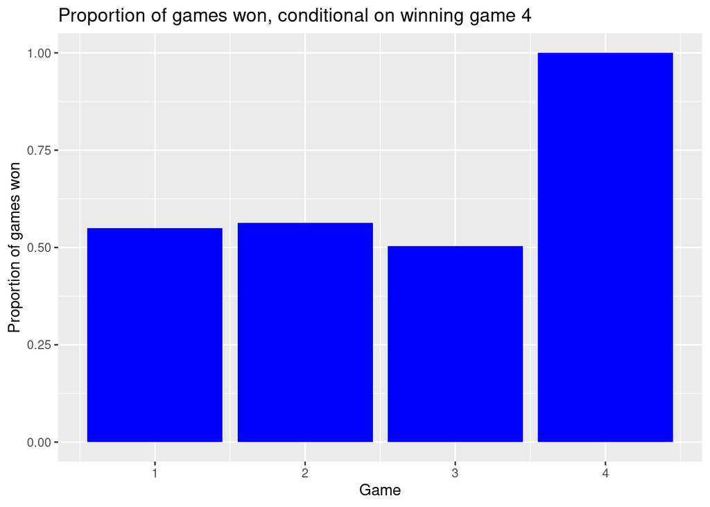

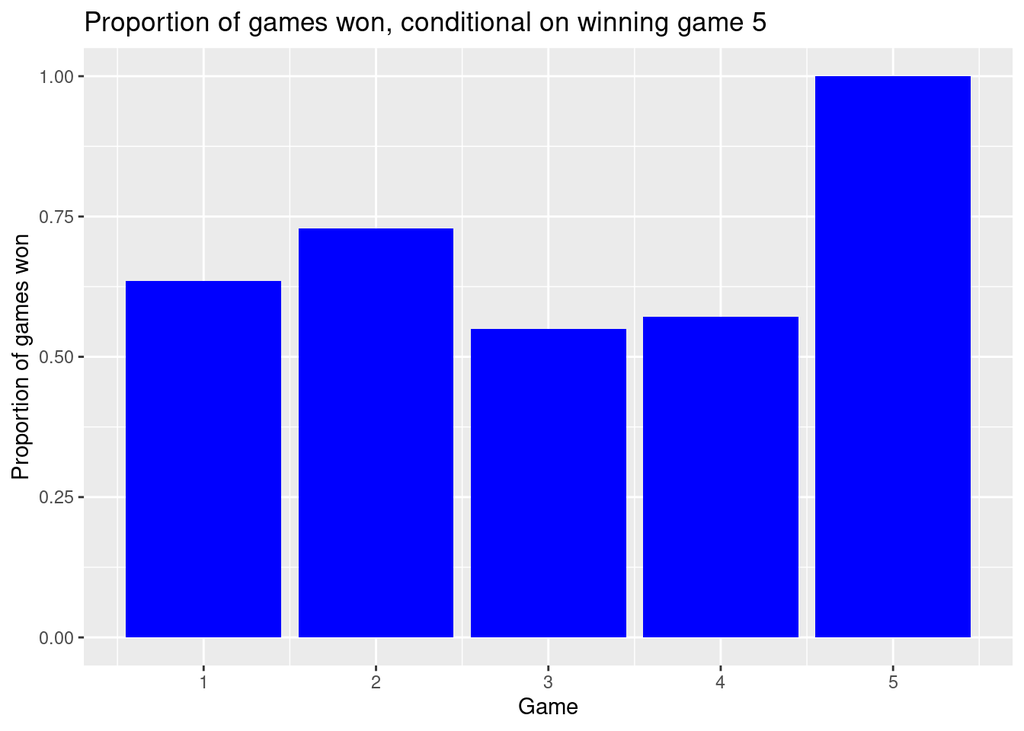

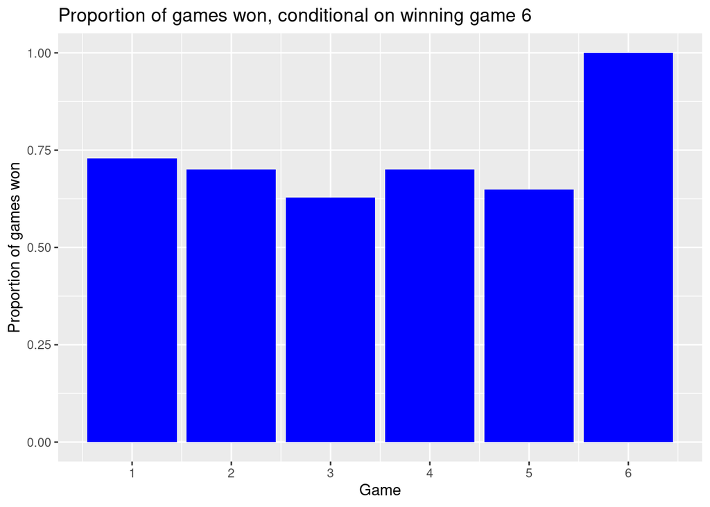

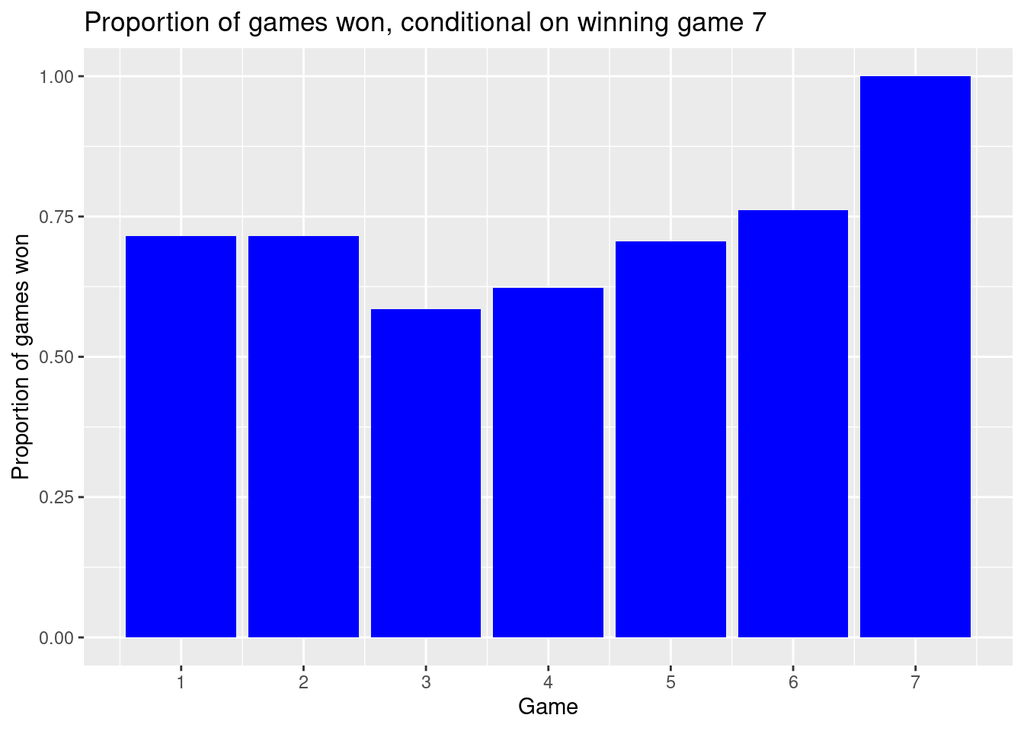

# Linear Probability Model - First Pass

We can model a playoff series with a linear model where we predict the outcome of a series and include indicator functions for whether a game was won or lost.

```
## # A tibble: 7 × 5
##   term           estimate std.error statistic  p.value
##   <chr>             <dbl>     <dbl>     <dbl>    <dbl>
## 1 (Intercept)      -0.950    0.139      -6.84 1.89e-10
## 2 win_game_1TRUE    0.537    0.0716      7.49 5.56e-12
## 3 win_game_2TRUE    0.545    0.0707      7.70 1.71e-12
## 4 win_game_3TRUE    0.555    0.0662      8.37 3.82e-14
## 5 win_game_4TRUE    0.545    0.0675      8.08 2.09e-13
## 6 win_game_5TRUE    0.487    0.0642      7.58 3.34e-12
## 7 win_game_6TRUE    0.425    0.0506      8.41 3.09e-14
```

For the next pass of the model, we restrict the sample to 4, 5, 6 and 7 game series and estimate separate regressions for each of those series lengths. We run into estimation problems galore with this approach. For a 4 game series, winning any single game means the series is already decided. And for a 5 game series, once we know the first 4 games and know that the series is 5 games long, we know perfectly well which team will win the series.

```
## # A tibble: 5 × 5
##   term            estimate std.error statistic  p.value
##   <chr>              <dbl>     <dbl>     <dbl>    <dbl>
## 1 (Intercept)    -4.79e-16  6.78e-17  -7.07e 0  3.82e-9
## 2 win_game_1TRUE  1   e+ 0  3.45e-17   2.90e16  0
## 3 win_game_2TRUE NA        NA         NA       NA
## 4 win_game_3TRUE NA        NA         NA       NA
## 5 p_win_game_1    1.63e-16  1.15e-16   1.41e 0  1.64e-1
```

```
## # A tibble: 5 × 5
##   term           estimate std.error statistic  p.value
##   <chr>             <dbl>     <dbl>     <dbl>    <dbl>
## 1 (Intercept)      -0.396    0.165      -2.39 1.93e- 2
## 2 win_game_1TRUE    0.380    0.0657      5.78 1.86e- 7
## 3 win_game_2TRUE    0.482    0.0617      7.81 3.75e-11
## 4 win_game_3TRUE    0.301    0.0515      5.84 1.47e- 7
## 5 p_win_game_1      0.716    0.251       2.86 5.58e- 3
```

```
## # A tibble: 6 × 5
##   term           estimate std.error statistic      p.value
##   <chr>             <dbl>     <dbl>     <dbl>        <dbl>
## 1 (Intercept)      -0.762    0.269      -2.83 0.00565
## 2 win_game_1TRUE    0.518    0.0897      5.77 0.000000108
## 3 win_game_2TRUE    0.522    0.0921      5.67 0.000000166
## 4 win_game_3TRUE    0.545    0.0892      6.11 0.0000000241
## 5 win_game_4TRUE    0.543    0.0911      5.96 0.0000000480
## 6 p_win_game_1      0.644    0.418       1.54 0.127
```

```
## # A tibble: 7 × 5
##   term           estimate std.error statistic p.value
##   <chr>             <dbl>     <dbl>     <dbl>   <dbl>
## 1 (Intercept)     0.0976      0.517    0.189    0.851
## 2 win_game_1TRUE  0.00200     0.198    0.0101   0.992
## 3 win_game_2TRUE -0.0128      0.203   -0.0633   0.950
## 4 win_game_3TRUE  0.0556      0.180    0.309    0.758
## 5 win_game_4TRUE  0.0239      0.176    0.136    0.893
## 6 win_game_5TRUE -0.137       0.155   -0.886    0.380
## 7 p_win_game_1    1.26        0.776    1.63     0.110
```

There is probably a more clever regression framework that would help explain us examine playoff series, but a Bayesian analysis sidesteps many of our previous issues.

# Reframing the Problem

The negative binomial distribution is based on an experiment satisfying the following conditions:

1. The experiment consists of a sequence of independent trials.
2. Each trial can result in either a success or a failure.
3. The probability of success $p$ is constant from trial to trial
4. The experiment continues until a total of $r$ successes have been observed

$$nb(k; r, p) \equiv \Pr(X = k) = \binom{k+r-1}{r-1} (1-p)^kp^r$$

Consider nb(x > 3; r = 4, p = .55) = P(X <= 3), the probability that at most 3 losses occur before 4 wins and the probability of winning each game is 55%.

`pnbinom(3, 4, .55, lower.tail = T) = .6082`

We should think about the outcomes of an NBA series as a negative binomial distribution. Given $r$ remaining games in the series and probability of winning a single game $p$, what is the likelihood that you win $k$ games?

# The binomial model for p

We can model $p$ using a generalized linear model (maybe this is overkill and we just talk about the logistic regression)

The GLM consists of three elements: 1. An exponential family of probability distributions. 2. A linear predictor $\eta = X \beta$ 3. A link function $g$ such that $E(Y \mid X) = p = g^{-1}(\eta)$

The logistic regression we choose after playing $n$ games is

$$p=\frac{\exp(\beta_0 + \sum_{i=1}^n \beta_iWonGame_i)}{1 + \exp(\beta_0 + \sum_{i=1}^n \beta_iWonGame_i)}$$
* probably skip the beta-distribution stuff since it’s only a 30-minute presentation

```
## GAMLSS-RS iteration 1: Global Deviance = 125.7843
## GAMLSS-RS iteration 2: Global Deviance = 125.7843
```

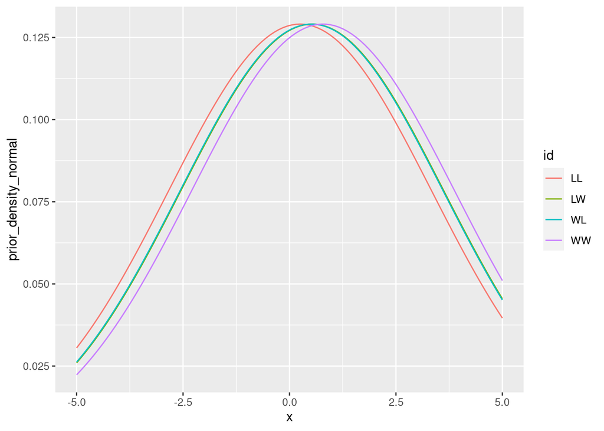

# Bayesian Regression

- same setup as logistic regression
- how to integrate ELO p_win_game_1?
- write-up on advantages of bayes methodology

```
##
## Model Info:
##  function:     stan_glm
##  family:       binomial [logit]
##  formula:      won_series ~ win_game_1 + win_game_2
##  algorithm:    sampling
##  sample:       4000 (posterior sample size)
##  priors:       see help('prior_summary')
##  observations: 97
##  predictors:   3
##
## Estimates:
##                  mean   sd   10%   50%   90%
## (Intercept)    -1.1    0.6 -1.9  -1.1  -0.4
## win_game_1TRUE  1.2    0.5  0.6   1.2   1.9
## win_game_2TRUE  1.3    0.5  0.6   1.3   1.9
##
## Fit Diagnostics:
##            mean   sd   10%   50%   90%
## mean_PPD 0.6    0.1  0.5   0.6   0.7
##
## The mean_ppd is the sample average posterior predictive distribution of the outcome variable (for details see help('summary.stanreg')).
##
## MCMC diagnostics
##                mcse Rhat n_eff
## (Intercept)    0.0  1.0  3116
## win_game_1TRUE 0.0  1.0  3003
## win_game_2TRUE 0.0  1.0  2906
## mean_PPD       0.0  1.0  3663
## log-posterior  0.0  1.0  2025
##
## For each parameter, mcse is Monte Carlo standard error, n_eff is a crude measure of effective sample size, and Rhat is the potential scale reduction factor on split chains (at convergence Rhat=1).
```

```
## Priors for model 'beta_normal_model_bayes'
## ------
## Intercept (after predictors centered)
##  ~ normal(location = 0, scale = 2.5)
##
## Coefficients
##   Specified prior:
##     ~ normal(location = [0,0], scale = [2.5,2.5])
##   Adjusted prior:
##     ~ normal(location = [0,0], scale = [5.29,5.33])
## ------
## See help('prior_summary.stanreg') for more details
```

```
## # A tibble: 3 × 3
##   term           estimate std.error
##   <chr>             <dbl>     <dbl>
## 1 (Intercept)       -1.10     0.585
## 2 win_game_1TRUE     1.18     0.499
## 3 win_game_2TRUE     1.26     0.505
```

```
##                        5%       95%
## (Intercept)    -2.1303178 -0.194867
## win_game_1TRUE  0.4010069  2.058179
## win_game_2TRUE  0.4316847  2.118140
```

[output not shown]

[output cut: 475 more lines]